# 01_Survival_analysis

jlgonrod

2024-01-02

# Libraries

The required libraries are loaded.

```r
# Load necessary libraries
library(survival)
library(forestplot)
library(ggplot2)
library(survminer)
library(ggdist)
library(dplyr)
library(writexl)
library(grid)
library(gridExtra)
library(cowplot)
```

# Functions

This R function performs survival analysis, evaluating the effect of vaccination status on survival outcomes for a specified day.

```r
# Function for Survival Analysis
analyze_survival <- function(data, time_var, status_var, vax_status, day) {

  # Subset data based on vaccination status
  subset_data <- subset(data, vaccinated == vax_status)

  # Fit survival model
  surv_model <- survfit(Surv(get(time_var), get(status_var)) ~ 1, data = subset_data)

  # Print summary without rounding
  cat(paste("Summary for", ifelse(vax_status == 1, "Vaccinated", "Non-Vaccinated"), "on Day", day, ":\n"))
  print(summary(surv_model, times = day))
}
```

This function performs survival analysis on a given dataframe, generates Kaplan-Meier survival plots stratified by vaccination status, and saves the plots as both PNG and TIFF files, without returning any values.

```r
generate_survival_plot <- function(df, plot_title, figure_number) {

  # Fit the survival model
  surv_model <- survfit(Surv(time=Survival_in_days, event=Status) ~ vaccinated, data = df)

  # Generate the plot
  plot <- ggsurvplot(
    surv_model,
    data = df,
    strat.by = "vaccinated",
    combine = TRUE,  # Combine the plots for different levels of 'vaccinated'
    pval = TRUE,
    pval.method= TRUE,
    conf.int = TRUE,
    legend.title = "Vaccination Status",
    legend.labs = c("Not Vaccinated", "Vaccinated"),
    risk.table = TRUE,
    palette=c("#f08080", "#90ee90"),
    title=plot_title,
    title.margin = margin(20, 0, 20, 0),
    xlab = "Days"
  )

  # Save the plot as png
  png(paste0("../OUTPUT_figures_tables/Figure_", figure_number, ".png"),
      width = 2400,
      height = 1600,
      res = 200,
      pointsize = 1)
  print(plot)
  dev.off()

  #Save the plot as tiff
  tiff(paste0("../OUTPUT_figures_tables/Figure_", figure_number, ".tiff"),
      width = 2400,
      height = 1600,
      res = 200,
      pointsize = 1)
  print(plot)
  dev.off()

  # Return the plot
  return(plot)
}
```

```r
generate_coxph_analysis <- function(dataframe, dependent_vars, group_name, num_table, num_fig){

  # Create the formula
  formula_string <- paste("Surv(Survival_in_days, Status) ~", paste(included_vars, collapse = " + "))
  formula <- as.formula(formula_string)

  # Model
  cox_model <- coxph(formula, data = dataframe)

  # Extract the model report
  cox_model_summary <- summary(cox_model_refined)

  # Extract the relevant_data
  coefficients <- as.data.frame(cox_model_summary$coefficients)
  intervals <- as.data.frame(cox_model_summary$conf.int)

  # Combine both df with relevant info
  cox_model_report <- cbind(coefficients, intervals[, c("lower .95", "upper .95")])

  # Change the names of the variables to be more descriptive
  rownames(cox_model_report) <- remap_rows[rownames(cox_model_report)]

  # Save the report in excel
  excel_path <- paste0("../OUTPUT_figures_tables/Table_", num_table, "_Cox_Model_Report_", group_name,".xlsx")

  cox_model_report_excel <- cox_model_report %>%
    mutate(variables = row.names(cox_model_report)) %>%
    select(variables, everything())
  write_xlsx(cox_model_report_excel, excel_path)

  # create the foresplot
  plot_title <- paste0("Forest Plot - Hazard ratio (with 95% Confidence Interval)\nRefined model | Group:", group_name)
  foresplot <- create_forest_plot(cox_model_report, plot_title, num_fig)

  return(list(cox_model_report, foresplot))
}
```

Function to generate the forestplot

```r
create_forest_plot <- function(cox_model_report, plot_title, n_figure) {

  cox_model_report <- cox_model_report %>%
    mutate(adverse_protective = case_when(`lower .95` > 1 & `upper .95` > 1 ~ "Adverse",
                                          `lower .95` < 1 & `upper .95` < 1 ~ "Protective",
                                          TRUE ~ "Inconclusive"),
           adverse_protective = as.factor(adverse_protective)
  )

  p <- ggplot(cox_model_report,
              aes(x = `exp(coef)`,
                  xmin = `lower .95`,
                  xmax = `upper .95`,
                  y = factor(rownames(cox_model_report), levels = rev(rownames(cox_model_report))))) +
    geom_point(aes(color = adverse_protective), size = 2) +
    geom_errorbarh(aes(color = adverse_protective), height = 0.1, linewidth = 0.5) +
    geom_vline(xintercept = 1, linetype = "dashed", color = "black") +
    labs(title = plot_title,
         x = "Hazard Ratio (HR)",
         y = "Predictor Variable") +
    scale_color_manual(name = "HR Impact",
                       values = c("Adverse" = "#C0392B",
                                  "Protective" = "#27ae60",
                                  "Inconclusive" = "gray70")) +
    theme_minimal() +
    theme(plot.title = element_text(hjust = 0.5, lineheight = 1.5))

  # Save as png
  png(paste("../OUTPUT_figures_tables/Figure_", n_figure, ".png", sep = ""),
      width = 1600,
      height = 2000,
      res = 200,
      pointsize = 1)
  print(p)
  dev.off()

  # Save as tiff
  tiff(paste("../OUTPUT_figures_tables/Figure_", n_figure, ".tiff", sep = ""),
       width = 1600,
       height = 2000,
       res = 200,
       pointsize = 1)
  print(p)
  dev.off()

  return(p)
}
```

# Load data

The df is imported and the variables that are not suitable for the analysis are removed. The important variables are renamed according to the analysis nomenclature.

```r
df <- read.csv("data/survival_data.csv")

# Remove columns no suitable for the analysis
df <- subset(df, select=-c(inpatient_days, admission_datetime,
                           discharge_datetime, death_datetime))

# Rename columns to be more interpretable
df <- df %>%
  rename(Status = hospital_outcome,
         Survival_in_days = followup_days)

# Check the structure of your dataframe
str(df)
```

```
## 'data.frame':    37274 obs. of  49 variables:
##  $ id                       : chr  "EN3000018260" "EN3004432218" "EN3028866917" "EN3033081376" ...
##  $ sex                      : int  0 0 0 1 0 0 1 1 0 0 ...
##  $ age                      : int  26 50 22 41 43 78 56 41 52 81 ...
##  $ num_shots                : int  0 2 0 0 0 3 0 0 0 2 ...
##  $ type_center              : chr  "County Hospital" "County Hospital" "County Hospital" "County Hospital" ...
##  $ vaccinated               : int  0 1 0 0 0 1 0 0 0 1 ...
##  $ icu                      : int  1 0 0 0 0 0 1 0 1 0 ...
##  $ Status                   : int  0 0 0 0 0 0 1 0 0 0 ...
##  $ Survival_in_days         : int  45 36 36 40 41 44 53 34 72 37 ...
##  $ wave_3                   : int  0 0 1 0 0 0 0 0 0 0 ...
##  $ wave_4                   : int  0 0 0 1 1 0 0 1 1 0 ...
##  $ wave_5                   : int  1 0 0 0 0 0 1 0 0 0 ...
##  $ wave_6                   : int  0 1 0 0 0 0 0 0 0 1 ...
##  $ wave_7                   : int  0 0 0 0 0 1 0 0 0 0 ...
```

[output cut: 35 more lines]

Set a more descriptive names for sex levels

```r
df$sex <- as.factor(df$sex)
df$sex <- recode(df$sex, "0" = "Female",
                         "1" = "Male")
```

Let’s encoded Waves as one categorical variable instead of 7 oneHotEncoding variables.

```r
# One-hot encoded columns
one_hot_columns <- grep("wave", colnames(df), value = TRUE)

# Get the index of the column with the maximum value in each row
original_column_index <- max.col(df[, one_hot_columns], "first")

# Get the name of the corresponding original column
original_column_name <- one_hot_columns[original_column_index]

# Add the original column to the DataFrame
df$wave <- original_column_name
df[1:10, c(one_hot_columns, "wave")]
```

```
##    wave_3 wave_4 wave_5 wave_6 wave_7   wave
## 1       0      0      1      0      0 wave_5
## 2       0      0      0      1      0 wave_6
## 3       1      0      0      0      0 wave_3
## 4       0      1      0      0      0 wave_4
## 5       0      1      0      0      0 wave_4
## 6       0      0      0      0      1 wave_7
## 7       0      0      1      0      0 wave_5
## 8       0      1      0      0      0 wave_4
## 9       0      1      0      0      0 wave_4
## 10      0      0      0      1      0 wave_6
```

```r
df$wave <- as.factor(df$wave)

rm(original_column_index, original_column_name)
```

Remove unused waves_x

```r
df <- df[, -which(names(df) %in% one_hot_columns)]
rm(one_hot_columns)
```

# 1. Analysis 1: CoxPH dichotomous vaccination.

Variables are reordered in the df. The variables ‘wave’ and ‘num_shots’ are not used as predictive variables in the model.

```r
# Specify the desired order of variables
desired_order <- c("Survival_in_days", "Status", "vaccinated", "sex", "age", "type_center", "icu", "wave")

# Get all variable names from the dataframe
variables <- colnames(df)

# Order the variables with specified order first, followed by the remaining variables in their original order
ordered_variables <- c(desired_order, setdiff(variables, desired_order))

# Order the columns in the df
df <- df %>%
  select(all_of(ordered_variables))

# get the descriptive variables
variables <- variables[!grepl(paste(c("Survival_in_days", "Status", "num_shots", "wave", "id"), collapse = "|"), variables)]

rm(ordered_variables, desired_order)
```

## 1.1. Train the model

The predictive model is then trained and plotted their coefficients as a forest p#lot.

```r
# Create the Cox model formula dynamically using the ordered and filtered variables
formula_string <- paste("Surv(Survival_in_days, Status) ~", paste(variables, collapse = " + "))
cox_model_formula <- as.formula(formula_string)

# Fit the Cox model using the specified formula and the dataframe
cox_model <- coxph(cox_model_formula, data = df)

# Obtain the summary of the Cox model
cox_model_summary <- summary(cox_model)

rm(variables, formula_string, cox_model_formula)
```

Review the model’s report.

```r
cox_model_summary
```

```
## Call:
## coxph(formula = cox_model_formula, data = df)
##
##   n= 37274, number of events= 7202
##
##                                       coef  exp(coef)   se(coef)      z
## sexMale                         -1.255e-01  8.820e-01  2.704e-02 -4.642
## age                              6.464e-02  1.067e+00  1.291e-03 50.055
## type_centerRegional Hospital    -8.549e-02  9.181e-01  3.055e-02 -2.799
## type_centerSpecialized Hospital -1.184e-01  8.883e-01  3.093e-02 -3.829
## vaccinated                      -2.302e-01  7.944e-01  2.648e-02 -8.692
## icu                              1.329e+00  3.777e+00  3.498e-02 37.993
## pmhx_activecancer                2.774e-01  1.320e+00  2.965e-02  9.354
## pmhx_asthma                     -1.075e-01  8.981e-01  4.095e-02 -2.625
## pmhx_chf                        -7.546e-02  9.273e-01  2.913e-02 -2.590
## pmhx_chronicliver                9.297e-02  1.097e+00  4.209e-02  2.209
## pmhx_ckd                        -2.450e-01  7.827e-01  3.231e-02 -7.581
## pmhx_copd                        4.605e-02  1.047e+00  2.885e-02  1.597
## pmhx_dementia                    1.202e-02  1.012e+00  2.867e-02  0.419
## pmhx_diabetes                   -3.317e-02  9.674e-01  2.715e-02 -1.222
## pmhx_hld                        -1.191e-01  8.878e-01  2.527e-02 -4.712
## pmhx_htn                        -3.471e-02  9.659e-01  3.520e-02 -0.986
## pmhx_ihd                         1.170e-01  1.124e+00  3.250e-02  3.601
## pmhx_obesity                    -5.020e-02  9.510e-01  3.046e-02 -1.648
## pmhx_stroke                     -2.380e-02  9.765e-01  4.606e-02 -0.517
## lab_alt                          3.088e-04  1.000e+00  2.597e-04  1.189
## lab_ast                          7.872e-06  1.000e+00  1.357e-04  0.058
## lab_creatinine                   2.252e-02  1.023e+00  1.559e-02  1.444
## lab_crp                          1.335e-03  1.001e+00  1.372e-04  9.725
## lab_ddimer                      -4.220e-07  1.000e+00  9.385e-07 -0.450
## lab_glucose                      1.091e-03  1.001e+00  1.485e-04  7.341
## lab_hct                         -5.887e-03  9.941e-01  1.437e-03 -4.096
## lab_hemoglobin                   7.570e-02  1.079e+00  3.788e-02  1.998
## lab_inr                          3.938e-02  1.040e+00  1.131e-02  3.481
## lab_ldh                          6.181e-04  1.001e+00  3.909e-05 15.812
## lab_leukocyte                   -3.885e-03  9.961e-01  9.270e-03 -0.419
## lab_lymphocyte                   5.079e-03  1.005e+00  1.058e-02  0.480
## lab_lymphocyte_percentage        7.179e-03  1.007e+00  4.035e-03  1.779
## lab_mch                         -1.879e-01  8.287e-01  1.894e-02 -9.922
## lab_mcv                          5.784e-02  1.060e+00  3.953e-03 14.631
```

[output cut: 84 more lines]

```
## lab_lymphocyte_percentage          1.0072     0.9928    0.9993    1.0152
## lab_mch                            0.8287     1.2067    0.7985    0.8600
## lab_mcv                            1.0595     0.9438    1.0514    1.0678
## lab_neutrophil                     1.0124     0.9877    0.9920    1.0333
## lab_neutrophil_percentage          1.0191     0.9813    1.0123    1.0260
## lab_platelet                       0.9986     1.0014    0.9983    0.9989
## lab_potassium                      1.0069     0.9932    0.9671    1.0483
## lab_rbc                            0.7349     1.3607    0.5880    0.9186
## lab_sodium                         1.0116     0.9885    1.0071    1.0162
## lab_urea                           1.0052     0.9948    1.0045    1.0059
##
## Concordance= 0.825  (se = 0.002 )
## Likelihood ratio test= 9960  on 41 df,   p=<2e-16
## Wald test            = 9078  on 41 df,   p=<2e-16
## Score (logrank) test = 11312  on 41 df,   p=<2e-16
```

## 1.2. ForestPlot

Get the relevant information from the model.

```r
coefficients <- as.data.frame(cox_model_summary$coefficients)
intervals <- as.data.frame(cox_model_summary$conf.int)

cox_model_report <- cbind(coefficients, intervals[, c("lower .95", "upper .95")])
rm(coefficients, intervals)
```

Let’s rename the row names to be more clear

```r
# Let's rename the variables to be more descriptives
remap_rows <- c(
  "vaccinated" = "Vaccinated",
  "sexMale" = "Sex Male",
  "age" = "Age",
  "type_centerSpecialized Hospital" = "Medical Center Type Specialty",
  "type_centerRegional Hospital" = "Medical Center Type Regional",
  "icu" = "ICU Stay",
  "wavewave_3" = "Wave 3",
  "wavewave_4" = "Wave 4",
  "wavewave_5" = "Wave 5",
  "wavewave_6" = "Wave 6",
  "wavewave_7" = "Wave 7",
  "pmhx_activecancer" = "Preexisting Condition Active Cancer",
  "pmhx_asthma" = "Preexisting Condition Asthma",
  "pmhx_chf" = "Preexisting Condition Congestive Heart Failure",
  "pmhx_chronicliver" = "Preexisting Condition Chronic Liver",
  "pmhx_ckd" = "Preexisting Condition Chronic Kidney Disease",
  "pmhx_copd" = "Preexisting Condition COPD",
  "pmhx_dementia" = "Preexisting Condition Dementia",
  "pmhx_diabetes" = "Preexisting Condition Diabetes",
  "pmhx_hld" = "Preexisting Condition Hyperlipidemia",
  "pmhx_htn" = "Preexisting Condition Hypertension",
  "pmhx_ihd" = "Preexisting Condition Ischemic Heart Disease",
  "pmhx_obesity" = "Preexisting Condition Obesity",
  "pmhx_stroke" = "Preexisting Condition Stroke",
  "lab_alt" = "Alanine Transaminase",
  "lab_ast" = "Aspartate Transaminase",
  "lab_creatinine" = "Creatinine",
  "lab_crp" = "C-Reactive Protein",
  "lab_ddimer" = "D-Dimer",
  "lab_glucose" = "Glucose",
  "lab_hct" = "Hematocrit",
  "lab_hemoglobin" = "Hemoglobin",
  "lab_inr" = "Normalized Prothrombin Time - INR",
  "lab_ldh" = "Lactate Dehydrogenase",
  "lab_leukocyte" = "Leukocyte Count",
  "lab_lymphocyte" = "Lymphocyte Count",
  "lab_lymphocyte_percentage" = "Lymphocyte Percentage",
  "lab_mch" = "Mean Corpuscular Hemoglobin",
  "lab_mcv" = "Mean Corpuscular Volume",
  "lab_neutrophil" = "Neutrophil Count",
  "lab_neutrophil_percentage" = "Neutrophil Percentage",
  "lab_platelet" = "Platelet Count",
  "lab_potassium" = "Potassium",
  "lab_rbc" = "Red Blood Cell Count",
  "lab_sodium" = "Sodium",
  "lab_urea" = "Urea"
)

# Assign new row names using the mapper, with handling for NA
new_row_names <- ifelse(rownames(cox_model_report) %in% names(remap_rows),
                        remap_rows[rownames(cox_model_report)],
                        rownames(cox_model_report))

# Assign the new row names to the DataFrame
rownames(cox_model_report) <- new_row_names
```

Save an excel with the model coefficients.

```r
# Create a new variable with the names and save it to excel
excel_path <- "../OUTPUT_figures_tables/Table_6_Cox_Model_Report.xlsx"

cox_model_report_excel <- cox_model_report %>%
  mutate(variables = row.names(cox_model_report)) %>%
  select(variables, everything())
write_xlsx(cox_model_report_excel, excel_path)

print(cox_model_report)
```

```
##                                                         coef exp(coef)
## Sex Male                                       -1.255269e-01 0.8820321
## Age                                             6.463905e-02 1.0667739
## Medical Center Type Regional                   -8.549036e-02 0.9180620
## Medical Center Type Specialty                  -1.184342e-01 0.8883102
## Vaccinated                                     -2.301698e-01 0.7943987
## ICU Stay                                        1.328972e+00 3.7771576
## Preexisting Condition Active Cancer             2.773529e-01 1.3196319
## Preexisting Condition Asthma                   -1.074891e-01 0.8980863
## Preexisting Condition Congestive Heart Failure -7.546049e-02 0.9273164
## Preexisting Condition Chronic Liver             9.296969e-02 1.0974285
## Preexisting Condition Chronic Kidney Disease   -2.449684e-01 0.7827293
## Preexisting Condition COPD                      4.605496e-02 1.0471320
## Preexisting Condition Dementia                  1.201652e-02 1.0120890
## Preexisting Condition Diabetes                 -3.317257e-02 0.9673716
## Preexisting Condition Hyperlipidemia           -1.190567e-01 0.8877575
## Preexisting Condition Hypertension             -3.470882e-02 0.9658866
## Preexisting Condition Ischemic Heart Disease    1.170377e-01 1.1241618
## Preexisting Condition Obesity                  -5.020007e-02 0.9510391
## Preexisting Condition Stroke                   -2.380259e-02 0.9764785
## Alanine Transaminase                            3.088045e-04 1.0003089
## Aspartate Transaminase                          7.871739e-06 1.0000079
## Creatinine                                      2.251770e-02 1.0227731
## C-Reactive Protein                              1.334593e-03 1.0013355
## D-Dimer                                        -4.219843e-07 0.9999996
## Glucose                                         1.090546e-03 1.0010911
## Hematocrit                                     -5.886663e-03 0.9941306
## Hemoglobin                                      7.569632e-02 1.0786350
## Normalized Prothrombin Time - INR               3.937661e-02 1.0401621
## Lactate Dehydrogenase                           6.180565e-04 1.0006182
## Leukocyte Count                                -3.885278e-03 0.9961223
## Lymphocyte Count                                5.078604e-03 1.0050915
## Lymphocyte Percentage                           7.178987e-03 1.0072048
## Mean Corpuscular Hemoglobin                    -1.879133e-01 0.8286866
## Mean Corpuscular Volume                         5.783656e-02 1.0595418
## Neutrophil Count                                1.236179e-02 1.0124385
## Neutrophil Percentage                           1.892455e-02 1.0191048
## Platelet Count                                 -1.433472e-03 0.9985676
## Potassium                                       6.852794e-03 1.0068763
## Red Blood Cell Count                           -3.079833e-01 0.7349276
```

[output cut: 113 more lines]

```
## Hemoglobin                                     1.1617711
## Normalized Prothrombin Time - INR              1.0634816
## Lactate Dehydrogenase                          1.0006949
## Leukocyte Count                                1.0143853
## Lymphocyte Count                               1.0261583
## Lymphocyte Percentage                          1.0152015
## Mean Corpuscular Hemoglobin                    0.8600263
## Mean Corpuscular Volume                        1.0677829
## Neutrophil Count                               1.0332685
## Neutrophil Percentage                          1.0259628
## Platelet Count                                 0.9988550
## Potassium                                      1.0483046
## Red Blood Cell Count                           0.9186468
## Sodium                                         1.0162234
## Urea                                           1.0058522
```

```r
rm(excel_path, cox_model_report_excel)
```

Generate the forestplot and save as tiff and png.

```r
# Create a variable factorial to indicate if the variable is a adverse or a protective effect
cox_model_report <- cox_model_report %>%
  mutate(adverse_protective = case_when(`lower .95` > 1 & `upper .95` > 1 ~ "Adverse",
                                        `lower .95` < 1 & `upper .95` < 1 ~ "Protective",
                                        TRUE ~ "Inconclusive"
    ),)
cox_model_report$adverse_protective <- as.factor(cox_model_report$adverse_protective)

p <-ggplot(cox_model_report,
           aes(x = `exp(coef)`,
               xmin = `lower .95`,
               xmax = `upper .95`,
               y = factor(rownames(cox_model_report), levels = rev(rownames(cox_model_report))))) +
  geom_point(aes(color = adverse_protective), size = 2) +  # Color según adverse_protective
  geom_errorbarh(aes(color = adverse_protective), height = 0.1, linewidth = 0.5) +  # Color según adverse_protective
  geom_vline(xintercept = 1, linetype = "dashed", color = "black") +
  labs(title = "Forest Plot - Hazard ratio (with 95% Confidence Interval)",
       x = "Hazard Ratio (HR)",
       y = "Predictor Variable") +
  scale_color_manual(name="HR Impact",
                     values = c("Adverse" = "#C0392B",
                                "Protective" = "#27ae60",
                                "Inconclusive" = "gray70")) +  # Asignar colores
  theme_minimal()+
  theme(
    plot.title = element_text(hjust = 0.5)
  )


n_figure <- 7

# Save as png
png(paste("../OUTPUT_figures_tables/Figure_", n_figure, ".png", sep=""),
    width = 1600,
    height = 2000,
    res = 200,
    pointsize = 1)
p
dev.off()
```

```r
# Save as tiff
tiff(paste("../OUTPUT_figures_tables/Figure_", n_figure, ".tiff", sep=""),
    width = 1600,
    height = 2000,
    res = 200,
    pointsize = 1)
p
dev.off()
```

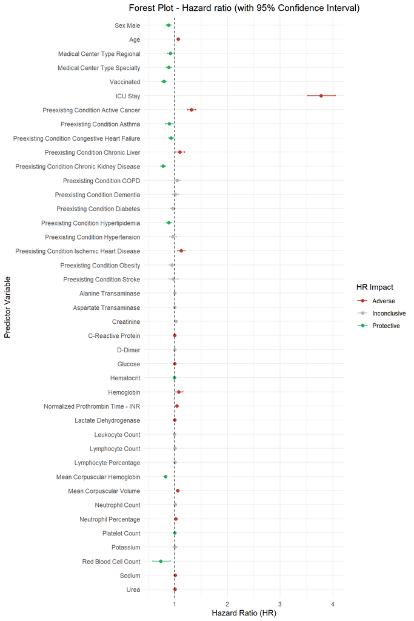

```r
# Plot
p
```

```r
rm(n_figure, p)
```

## 1.3. CoxPH Refined

Laboratory variables lacking statistical significance will be eliminated in the analysis.

```r
# Undo remapping
original_row_names <- names(remap_rows)
rownames(cox_model_report) <- original_row_names[match(rownames(cox_model_report), remap_rows)]
index_lab <- grep("^lab_",rownames(cox_model_report))[1]

# Keeps previous significal labs_variables
labs_variables <- rownames(cox_model_report)[index_lab:nrow(cox_model_report)]
sign_lab <- cox_model_report[labs_variables, ] %>%
  filter(`Pr(>|z|)` < 0.05) %>%
  rownames

# Get previous variables
other_vars <- colnames(df)[1:(grep("^lab_", colnames(df))[1]-1)]
other_vars <- other_vars[!other_vars %in% c("Status", "Survival_in_days", "num_shots", "wave")]

rm(original_row_names, index_lab)
```

Let’s print the variables removed

```r
removed_lab <- setdiff(labs_variables, sign_lab)
cat("Removed variables:\n")
```

```
## Removed variables:
```

```r
cat(paste("\t", remap_rows[removed_lab], sep = ""), sep = "\n")
```

```
##  Alanine Transaminase
##  Aspartate Transaminase
##  Creatinine
##  D-Dimer
##  Leukocyte Count
##  Lymphocyte Count
##  Lymphocyte Percentage
##  Neutrophil Count
##  Potassium
```

```r
rm(removed_lab)

rm(labs_variables)
```

Let’s generate the formula and retrain the model

```r
# Create the formula
included_vars <- c(other_vars, sign_lab)
included_vars <- setdiff(included_vars, c("id"))

# Create the formula
formula_string <- paste("Surv(Survival_in_days, Status) ~", paste(included_vars, collapse = " + "))
formula <- as.formula(formula_string)

# Model
cox_model_refined <- coxph(formula, data = df)

# Extract the model report
cox_model_refined_summary <- summary(cox_model_refined)
cox_model_refined_summary
```

```
## Call:
## coxph(formula = formula, data = df)
##
##   n= 37274, number of events= 7202
##
##                                       coef  exp(coef)   se(coef)       z
## vaccinated                      -0.2216250  0.8012158  0.0261051  -8.490
## sexMale                         -0.1282755  0.8796110  0.0267073  -4.803
## age                              0.0643902  1.0665085  0.0012761  50.457
## type_centerRegional Hospital    -0.0828817  0.9204600  0.0304332  -2.723
## type_centerSpecialized Hospital -0.1181800  0.8885361  0.0307997  -3.837
## icu                              1.3309541  3.7846525  0.0349263  38.107
## pmhx_activecancer                0.2851477  1.3299584  0.0295466   9.651
## pmhx_asthma                     -0.1058344  0.8995736  0.0409355  -2.585
## pmhx_chf                        -0.0777970  0.9251522  0.0290777  -2.675
## pmhx_chronicliver                0.0925725  1.0969927  0.0420839   2.200
## pmhx_ckd                        -0.2353885  0.7902638  0.0314453  -7.486
## pmhx_copd                        0.0430103  1.0439487  0.0288159   1.493
## pmhx_dementia                    0.0093237  1.0093673  0.0286601   0.325
## pmhx_diabetes                   -0.0374705  0.9632228  0.0270976  -1.383
## pmhx_hld                        -0.1209216  0.8861034  0.0252492  -4.789
## pmhx_htn                        -0.0353141  0.9653022  0.0351403  -1.005
## pmhx_ihd                         0.1190267  1.1264000  0.0324822   3.664
## pmhx_obesity                    -0.0512968  0.9499967  0.0304452  -1.685
## pmhx_stroke                     -0.0303595  0.9700967  0.0459402  -0.661
## lab_crp                          0.0013811  1.0013821  0.0001358  10.172
## lab_glucose                      0.0011311  1.0011318  0.0001467   7.712
## lab_hct                         -0.0061534  0.9938655  0.0014290  -4.306
## lab_hemoglobin                   0.0958876  1.1006354  0.0355519   2.697
## lab_inr                          0.0383242  1.0390680  0.0112901   3.394
## lab_ldh                          0.0006618  1.0006620  0.0000270  24.514
## lab_mch                         -0.1997657  0.8189226  0.0175869 -11.359
## lab_mcv                          0.0593255  1.0611206  0.0038092  15.574
## lab_neutrophil_percentage        0.0144924  1.0145979  0.0011940  12.138
## lab_platelet                    -0.0013323  0.9986686  0.0001399  -9.524
## lab_rbc                         -0.3588272  0.6984950  0.1074561  -3.339
## lab_sodium                       0.0114811  1.0115473  0.0022338   5.140
## lab_urea                         0.0056579  1.0056740  0.0002332  24.262
##                                 Pr(>|z|)
## vaccinated                       < 2e-16 ***
```

[output cut: 57 more lines]

```
## lab_hemoglobin                     1.1006     0.9086    1.0266    1.1801
## lab_inr                            1.0391     0.9624    1.0163    1.0623
## lab_ldh                            1.0007     0.9993    1.0006    1.0007
## lab_mch                            0.8189     1.2211    0.7912    0.8476
## lab_mcv                            1.0611     0.9424    1.0532    1.0691
## lab_neutrophil_percentage          1.0146     0.9856    1.0122    1.0170
## lab_platelet                       0.9987     1.0013    0.9984    0.9989
## lab_rbc                            0.6985     1.4316    0.5658    0.8622
## lab_sodium                         1.0115     0.9886    1.0071    1.0160
## lab_urea                           1.0057     0.9944    1.0052    1.0061
##
## Concordance= 0.825  (se = 0.002 )
## Likelihood ratio test= 9940  on 32 df,   p=<2e-16
## Wald test            = 9022  on 32 df,   p=<2e-16
## Score (logrank) test = 11140  on 32 df,   p=<2e-16
```

```r
rm(formula, formula_string, other_vars, sign_lab)
```

Let’s extract the information relevant from the model report.

```r
coefficients <- as.data.frame(cox_model_refined_summary$coefficients)
intervals <- as.data.frame(cox_model_refined_summary$conf.int)

cox_model_refined_report <- cbind(coefficients, intervals[, c("lower .95", "upper .95")])
rm(coefficients, intervals)

rownames(cox_model_refined_report) <- remap_rows[rownames(cox_model_refined_report)]
```

Save it in an excel.

```r
# Save the report in excel
excel_path <- "../OUTPUT_figures_tables/Table_7_Cox_Model_Refined_Report.xlsx"

cox_model_report_refined_excel <- cox_model_refined_report %>%
  mutate(variables = row.names(cox_model_refined_report)) %>%
  select(variables, everything())
write_xlsx(cox_model_report_refined_excel, excel_path)

print(cox_model_refined_report)
```

```
##                                                         coef exp(coef)
## Vaccinated                                     -0.2216249682 0.8012158
## Sex Male                                       -0.1282755045 0.8796110
## Age                                             0.0643902263 1.0665085
## Medical Center Type Regional                   -0.0828817248 0.9204600
## Medical Center Type Specialty                  -0.1181800193 0.8885361
## ICU Stay                                        1.3309540740 3.7846525
## Preexisting Condition Active Cancer             0.2851476950 1.3299584
## Preexisting Condition Asthma                   -0.1058343578 0.8995736
## Preexisting Condition Congestive Heart Failure -0.0777970347 0.9251522
## Preexisting Condition Chronic Liver             0.0925725204 1.0969927
## Preexisting Condition Chronic Kidney Disease   -0.2353885067 0.7902638
## Preexisting Condition COPD                      0.0430103388 1.0439487
## Preexisting Condition Dementia                  0.0093236853 1.0093673
## Preexisting Condition Diabetes                 -0.0374705381 0.9632228
## Preexisting Condition Hyperlipidemia           -0.1209216384 0.8861034
## Preexisting Condition Hypertension             -0.0353140933 0.9653022
## Preexisting Condition Ischemic Heart Disease    0.1190267414 1.1264000
## Preexisting Condition Obesity                  -0.0512967890 0.9499967
## Preexisting Condition Stroke                   -0.0303595327 0.9700967
## C-Reactive Protein                              0.0013811303 1.0013821
## Glucose                                         0.0011311097 1.0011317
## Hematocrit                                     -0.0061534057 0.9938655
## Hemoglobin                                      0.0958876085 1.1006354
## Normalized Prothrombin Time - INR               0.0383241692 1.0390680
## Lactate Dehydrogenase                           0.0006617897 1.0006620
## Mean Corpuscular Hemoglobin                    -0.1997656950 0.8189226
## Mean Corpuscular Volume                         0.0593255269 1.0611206
## Neutrophil Percentage                           0.0144923788 1.0145979
## Platelet Count                                 -0.0013322478 0.9986686
## Red Blood Cell Count                           -0.3588272020 0.6984950
## Sodium                                          0.0114811229 1.0115473
## Urea                                            0.0056579144 1.0056740
##                                                    se(coef)           z
## Vaccinated                                     2.610505e-02  -8.4897369
## Sex Male                                       2.670726e-02  -4.8030204
## Age                                            1.276137e-03  50.4571381
## Medical Center Type Regional                   3.043320e-02  -2.7233981
## Medical Center Type Specialty                  3.079970e-02  -3.8370504
## ICU Stay                                       3.492631e-02  38.1074942
```

[output cut: 77 more lines]

```
## Preexisting Condition Obesity                  1.0084098
## Preexisting Condition Stroke                   1.0614986
## C-Reactive Protein                             1.0016486
## Glucose                                        1.0014196
## Hematocrit                                     0.9966529
## Hemoglobin                                     1.1800632
## Normalized Prothrombin Time - INR              1.0623171
## Lactate Dehydrogenase                          1.0007150
## Mean Corpuscular Hemoglobin                    0.8476428
## Mean Corpuscular Volume                        1.0690724
## Neutrophil Percentage                          1.0169750
## Platelet Count                                 0.9989425
## Red Blood Cell Count                           0.8622439
## Sodium                                         1.0159858
## Urea                                           1.0061337
```

```r
rm(excel_path, cox_model_report_refined_excel)
```

## 1.4. ForesPlot

```r
# Create a variable factorial to indicate if the variable is a adverse or a protective effect
cox_model_refined_report <- cox_model_refined_report %>%
  mutate(adverse_protective = case_when(`lower .95` > 1 & `upper .95` > 1 ~ "Adverse",
                                        `lower .95` < 1 & `upper .95` < 1 ~ "Protective",
                                        TRUE ~ "Inconclusive"
    ),)
cox_model_refined_report$adverse_protective <- as.factor(cox_model_refined_report$adverse_protective)

p <-ggplot(cox_model_refined_report,
           aes(x = `exp(coef)`,
               xmin = `lower .95`,
               xmax = `upper .95`,
               y = factor(rownames(cox_model_refined_report), levels = rev(rownames(cox_model_refined_report))))) +
  geom_point(aes(color = adverse_protective), size = 2) +  # Color según adverse_protective
  geom_errorbarh(aes(color = adverse_protective), height = 0.3, linewidth = 0.5) +  # Color según adverse_protective
  geom_vline(xintercept = 1, linetype = "dashed", color = "black") +
  labs(title = "Forest Plot - Hazard ratio (with 95% Confidence Interval)\nRefined model",
       x = "Hazard Ratio (HR)",
       y = "Predictor Variable") +
  scale_color_manual(name="HR Impact",
                     values = c("Adverse" = "#C0392B",
                                "Protective" = "#27ae60",
                                "Inconclusive" = "gray70")) +  # Asignar colores
  theme_minimal()+
  theme(
    plot.title = element_text(hjust = 0.5)
  )


n_figure <- 8

cat(n_figure)
```

```
## 8
```

```r
# Save as png
png(paste("../OUTPUT_figures_tables/Figure_", n_figure, ".png", sep=""),
    width = 1600,
    height = 2000,
    res = 200,
    pointsize = 1)
p
dev.off()
```

```r
# Save as tiff
tiff(paste("../OUTPUT_figures_tables/Figure_", n_figure, ".tiff", sep=""),
    width = 1600,
    height = 2000,
    res = 200,
    pointsize = 1)
p
dev.off()
```

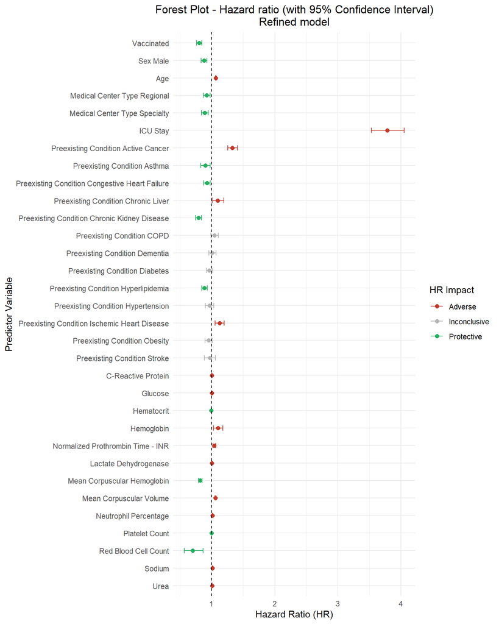

```r
p
```

```r
rm(p, n_figure)
```

## 1.5 Adjusted Survival Curves for Cox Proportional Hazards Model

```r
df<-as.data.frame(df)

df$vaccinated <-factor(
  df$vaccinated, levels = 0:1,
  labels = c("Unvaccinated", "Vaccinated")
)

vars_descriptives <- included_vars[included_vars != "vaccinated"]

# Create the formula
string_formula <- paste("Surv(Survival_in_days, Status) ~ strata(vaccinated) + ",
                          paste(vars_descriptives, collapse = " + "))
formula <- as.formula(string_formula)

# Fit the Cox proportional hazards model with stratification by vaccinated status
fit <- coxph(formula, data = df)

# Plot adjusted survival curves stratified by vaccinated status
custom_colors <- c("Unvaccinated" = "#f08080", "Vaccinated" = "#90ee90")
title = "Adjusted Survival Curves for Cox Proportional Hazards Model Refined"
ajusted_curve <- ggadjustedcurves(fit,variable = 'vaccinated',
                                       legend.title = "Vaccination Status",
                                       main=title,
                                       palette=custom_colors,
                                       xlab='Days')
figure_number <- 9

# Save the plot as png
png(paste0("../OUTPUT_figures_tables/Figure_", figure_number, ".png"),
    width = 2400,
    height = 1600,
    res = 200,
    pointsize = 7)
print(ajusted_curve)
dev.off()
```

```r
#Save the plot as tiff
tiff(paste0("../OUTPUT_figures_tables/Figure_", figure_number, ".tiff"),
    width = 2400,
    height = 1600,
    res = 200,
    pointsize = 7)
print(ajusted_curve)
dev.off()
```

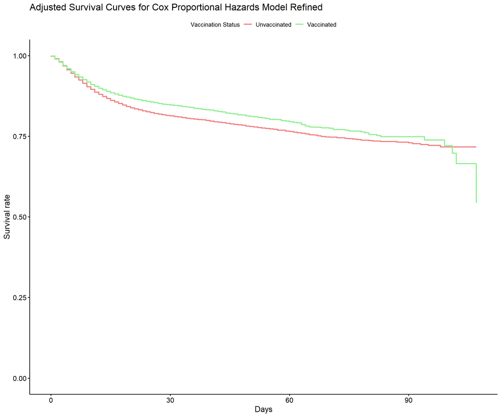

```r
# print the plot
print(ajusted_curve)
```

# 2. Analysis 2: Sub-analysis stratified by age group.

## 2.1. Load the data

Load the csv

```r
df <- read.csv("data/survival_data.csv")

# Remove columns no suitable for the analysis
df <- subset(df, select=-c(inpatient_days,
                           discharge_datetime,
                           death_datetime))
# cast admission_datetime from chr to Date
df$admission_datetime <- as.Date(df$admission_datetime, format = "%Y-%m-%d")

# Rename columns to be more interpretable
df <- df %>%
  rename(Status = hospital_outcome,
         Survival_in_days = followup_days)

# Rename sex levels
df$sex <- as.factor(df$sex)
df$sex <- recode(df$sex, "0" = "Female",
                         "1" = "Male")

# Remove wave columns
one_hot_columns <- grep("wave", colnames(df), value = TRUE)
df <- df[, -which(names(df) %in% one_hot_columns)]
rm(one_hot_columns)
```

```r
################## GROUP A: >= 80 YEARS, INIT 2020-12-27 ##################
age_boundary<- 80
date_boundary <- as.Date("2020-12-27") + 14 # 14 days after as it represents the start of protection after vaccination.

df_over80 <- df%>%
  filter(age >= age_boundary,
         admission_datetime >= date_boundary) %>%
  select(-c("id"))



################## GROUP B: >= 70 YEARS, INIT 2021-04-05 ##################
age_boundary<- 70
date_boundary <- as.Date("2021-04-05") + 14 # 14 days after

df_over70 <- df%>%
  filter(age >= age_boundary,
         admission_datetime >= date_boundary) %>%
  select(-c("id"))

################## GROUP C: >= 60 YEARS, INIT 2021-05-03 ##################
age_boundary<- 60
date_boundary <- as.Date("2021-05-03") + 14 # 14 days after

df_over60 <- df%>%
  filter(age >= age_boundary,
         admission_datetime >= date_boundary) %>%
  select(-c("id"))

################## GROUP D: >= 40 YEARS, INIT 2021-06-01 ##################
age_boundary<- 40
date_boundary <- as.Date("2021-06-01") + 14 # 14 days after

df_over40 <- df%>%
  filter(age >= age_boundary,
         admission_datetime >= date_boundary) %>%
  select(-c("id"))

################## GROUP E: >= 18 YEARS, INIT 2021-07-20 ##################
age_boundary<- 18
date_boundary <- as.Date("2021-07-20") + 14 # 14 days after

df_over18 <- df%>%
  filter(age >= age_boundary,
         admission_datetime >= date_boundary) %>%
  select(-c("id"))
###########################################################################

rm(age_boundary, date_boundary)
```

## 2.2. Analysis A: over 80

Age: >= 80

Admission date: after or equal 27/12/2020 + 14 days

```r
cat("Check the subset:\n")
```

```
## Check the subset:
```

```r
summary(df_over80[, c("age", "admission_datetime")])
```

```
##       age         admission_datetime
##  Min.   : 80.00   Min.   :2021-01-10
##  1st Qu.: 83.00   1st Qu.:2021-02-20
##  Median : 86.00   Median :2022-01-12
##  Mean   : 86.54   Mean   :2021-11-07
##  3rd Qu.: 89.00   3rd Qu.:2022-05-15
##  Max.   :105.00   Max.   :2022-11-25
```

```r
cat("\nNumber rows:", nrow(df_over80))
```

```
##
## Number rows: 9567
```

### 2.2.1 CoxPH refined (Group A)

```r
generate_coxph_analysis(df_over80,
                        included_vars,
                        "Over 80 years (Group A)",
                        num_table = 8,
                        num_fig = 10)
```

```
## [[1]]
##                                                         coef exp(coef)
## Vaccinated                                     -0.2216249682 0.8012158
## Sex Male                                       -0.1282755045 0.8796110
## Age                                             0.0643902263 1.0665085
## Medical Center Type Regional                   -0.0828817248 0.9204600
## Medical Center Type Specialty                  -0.1181800193 0.8885361
## ICU Stay                                        1.3309540740 3.7846525
## Preexisting Condition Active Cancer             0.2851476950 1.3299584
## Preexisting Condition Asthma                   -0.1058343578 0.8995736
## Preexisting Condition Congestive Heart Failure -0.0777970347 0.9251522
## Preexisting Condition Chronic Liver             0.0925725204 1.0969927
## Preexisting Condition Chronic Kidney Disease   -0.2353885067 0.7902638
## Preexisting Condition COPD                      0.0430103388 1.0439487
## Preexisting Condition Dementia                  0.0093236853 1.0093673
## Preexisting Condition Diabetes                 -0.0374705381 0.9632228
## Preexisting Condition Hyperlipidemia           -0.1209216384 0.8861034
## Preexisting Condition Hypertension             -0.0353140933 0.9653022
## Preexisting Condition Ischemic Heart Disease    0.1190267414 1.1264000
## Preexisting Condition Obesity                  -0.0512967890 0.9499967
## Preexisting Condition Stroke                   -0.0303595327 0.9700967
## C-Reactive Protein                              0.0013811303 1.0013821
## Glucose                                         0.0011311097 1.0011317
## Hematocrit                                     -0.0061534057 0.9938655
## Hemoglobin                                      0.0958876085 1.1006354
## Normalized Prothrombin Time - INR               0.0383241692 1.0390680
## Lactate Dehydrogenase                           0.0006617897 1.0006620
## Mean Corpuscular Hemoglobin                    -0.1997656950 0.8189226
## Mean Corpuscular Volume                         0.0593255269 1.0611206
## Neutrophil Percentage                           0.0144923788 1.0145979
## Platelet Count                                 -0.0013322478 0.9986686
## Red Blood Cell Count                           -0.3588272020 0.6984950
## Sodium                                          0.0114811229 1.0115473
## Urea                                            0.0056579144 1.0056740
##                                                    se(coef)           z
## Vaccinated                                     2.610505e-02  -8.4897369
## Sex Male                                       2.670726e-02  -4.8030204
## Age                                            1.276137e-03  50.4571381
## Medical Center Type Regional                   3.043320e-02  -2.7233981
## Medical Center Type Specialty                  3.079970e-02  -3.8370504
```

[output cut: 80 more lines]

```
## C-Reactive Protein                             1.0016486
## Glucose                                        1.0014196
## Hematocrit                                     0.9966529
## Hemoglobin                                     1.1800632
## Normalized Prothrombin Time - INR              1.0623171
## Lactate Dehydrogenase                          1.0007150
## Mean Corpuscular Hemoglobin                    0.8476428
## Mean Corpuscular Volume                        1.0690724
## Neutrophil Percentage                          1.0169750
## Platelet Count                                 0.9989425
## Red Blood Cell Count                           0.8622439
## Sodium                                         1.0159858
## Urea                                           1.0061337
##
## [[2]]
```

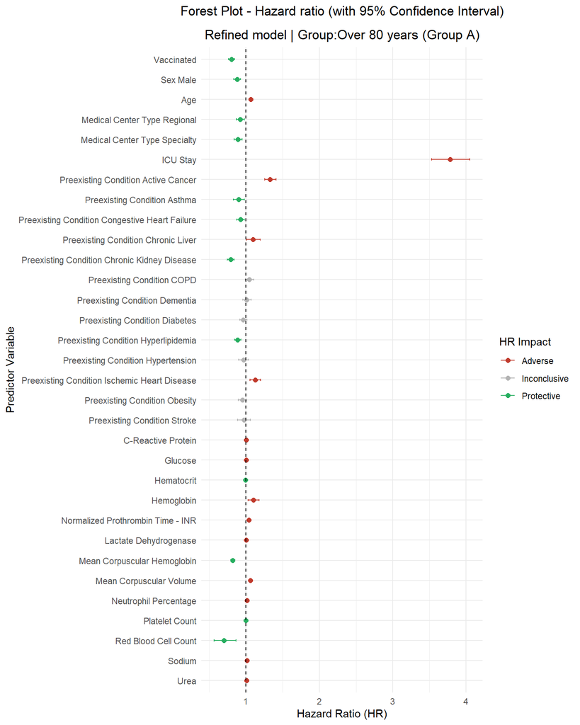

### 2.2.2. Adjusted Survival Curves for Cox Proportional Hazards Model (group A)

Comparison will be made between survival curves of individuals aged 80 and above, stratified based on vaccination status, following verification of admission dates. The curved is ajusted using the CoxPH model.

```r
df_over80<-as.data.frame(df_over80)

df_over80$vaccinated <-factor(
  df_over80$vaccinated, levels = 0:1,
  labels = c("Unvaccinated", "Vaccinated")
)

vars_descriptives <- included_vars[included_vars != "vaccinated"]

# Create the formula
string_formula <- paste("Surv(Survival_in_days, Status) ~ strata(vaccinated) + ",
                          paste(vars_descriptives, collapse = " + "))
formula <- as.formula(string_formula)

# Fit the Cox proportional hazards model with stratification by vaccinated status
fit <- coxph(formula, data = df_over80)

# Plot adjusted survival curves stratified by vaccinated status
custom_colors <- c("Unvaccinated" = "#f08080", "Vaccinated" = "#90ee90")
title = "Adjusted Survival Curves for Cox Proportional Hazards Model\nGroup A | ≥ 80 years"
ajusted_curve_A <- ggadjustedcurves(fit,variable = 'vaccinated',
                                       legend.title = "Vaccination Status",
                                       main=title,
                                       palette=custom_colors,
                                       xlab='Days')
figure_number <- 11

# Save the plot as png
png(paste0("../OUTPUT_figures_tables/Figure_", figure_number, ".png"),
    width = 2400,
    height = 1600,
    res = 200,
    pointsize = 7)
print(ajusted_curve_A)
dev.off()
```

```r
#Save the plot as tiff
tiff(paste0("../OUTPUT_figures_tables/Figure_", figure_number, ".tiff"),
    width = 2400,
    height = 1600,
    res = 200,
    pointsize = 7)
print(ajusted_curve_A)
dev.off()
```

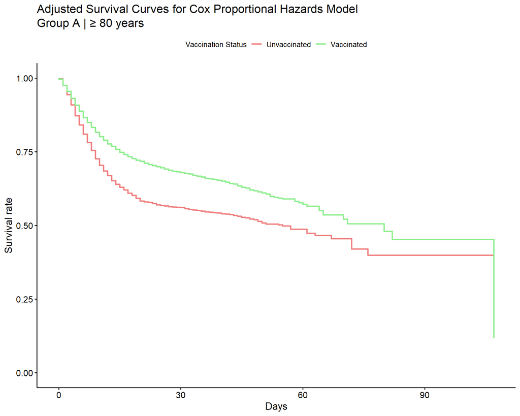

```r
# print the plot
print(ajusted_curve_A)
```

## 2.3. Analysis B: over 70

Age: >= 70

Admission date: after or equal 05/04/2021 + 14 days

```r
cat("Check the subset:\n")
```

```
## Check the subset:
```

```r
summary(df_over70[, c("age", "admission_datetime")])
```

```
##       age        admission_datetime
##  Min.   : 70.0   Min.   :2021-04-19
##  1st Qu.: 76.0   1st Qu.:2021-12-19
##  Median : 82.0   Median :2022-02-22
##  Mean   : 82.2   Mean   :2022-02-20
##  3rd Qu.: 88.0   3rd Qu.:2022-06-14
##  Max.   :105.0   Max.   :2022-11-28
```

```r
cat("\nNumber rows:", nrow(df_over70))
```

```
##
## Number rows: 10910
```

### 2.3.1 CoxPH refined (Group B)

```r
generate_coxph_analysis(df_over70,
                        included_vars,
                        "Over 70 years (Group B)",
                        num_table = 9,
                        num_fig = 12)
```

```
## [[1]]
##                                                         coef exp(coef)
## Vaccinated                                     -0.2216249682 0.8012158
## Sex Male                                       -0.1282755045 0.8796110
## Age                                             0.0643902263 1.0665085
## Medical Center Type Regional                   -0.0828817248 0.9204600
## Medical Center Type Specialty                  -0.1181800193 0.8885361
## ICU Stay                                        1.3309540740 3.7846525
## Preexisting Condition Active Cancer             0.2851476950 1.3299584
## Preexisting Condition Asthma                   -0.1058343578 0.8995736
## Preexisting Condition Congestive Heart Failure -0.0777970347 0.9251522
## Preexisting Condition Chronic Liver             0.0925725204 1.0969927
## Preexisting Condition Chronic Kidney Disease   -0.2353885067 0.7902638
## Preexisting Condition COPD                      0.0430103388 1.0439487
## Preexisting Condition Dementia                  0.0093236853 1.0093673
## Preexisting Condition Diabetes                 -0.0374705381 0.9632228
## Preexisting Condition Hyperlipidemia           -0.1209216384 0.8861034
## Preexisting Condition Hypertension             -0.0353140933 0.9653022
## Preexisting Condition Ischemic Heart Disease    0.1190267414 1.1264000
## Preexisting Condition Obesity                  -0.0512967890 0.9499967
## Preexisting Condition Stroke                   -0.0303595327 0.9700967
## C-Reactive Protein                              0.0013811303 1.0013821
## Glucose                                         0.0011311097 1.0011317
## Hematocrit                                     -0.0061534057 0.9938655
## Hemoglobin                                      0.0958876085 1.1006354
## Normalized Prothrombin Time - INR               0.0383241692 1.0390680
## Lactate Dehydrogenase                           0.0006617897 1.0006620
## Mean Corpuscular Hemoglobin                    -0.1997656950 0.8189226
## Mean Corpuscular Volume                         0.0593255269 1.0611206
## Neutrophil Percentage                           0.0144923788 1.0145979
## Platelet Count                                 -0.0013322478 0.9986686
## Red Blood Cell Count                           -0.3588272020 0.6984950
## Sodium                                          0.0114811229 1.0115473
## Urea                                            0.0056579144 1.0056740
##                                                    se(coef)           z
## Vaccinated                                     2.610505e-02  -8.4897369
## Sex Male                                       2.670726e-02  -4.8030204
## Age                                            1.276137e-03  50.4571381
## Medical Center Type Regional                   3.043320e-02  -2.7233981
## Medical Center Type Specialty                  3.079970e-02  -3.8370504
```

[output cut: 80 more lines]

```
## C-Reactive Protein                             1.0016486
## Glucose                                        1.0014196
## Hematocrit                                     0.9966529
## Hemoglobin                                     1.1800632
## Normalized Prothrombin Time - INR              1.0623171
## Lactate Dehydrogenase                          1.0007150
## Mean Corpuscular Hemoglobin                    0.8476428
## Mean Corpuscular Volume                        1.0690724
## Neutrophil Percentage                          1.0169750
## Platelet Count                                 0.9989425
## Red Blood Cell Count                           0.8622439
## Sodium                                         1.0159858
## Urea                                           1.0061337
##
## [[2]]
```

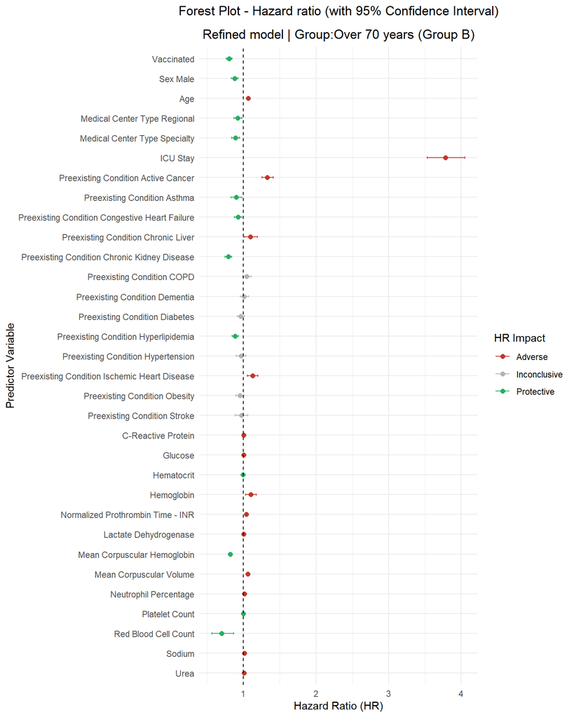

### 2.3.2. Adjusted Survival Curves for Cox Proportional Hazards Model (group B)

Comparison will be made between survival curves of individuals aged 70 and above, stratified based on vaccination status, following verification of admission dates.

```r
df_over70<-as.data.frame(df_over70)

df_over70$vaccinated <-factor(
  df_over70$vaccinated, levels = 0:1,
  labels = c("Unvaccinated", "Vaccinated")
)

vars_descriptives <- included_vars[included_vars != "vaccinated"]

# Create the formula
string_formula <- paste("Surv(Survival_in_days, Status) ~ strata(vaccinated) + ",
                          paste(vars_descriptives, collapse = " + "))
formula <- as.formula(string_formula)

# Fit the Cox proportional hazards model with stratification by vaccinated status
fit <- coxph(formula, data = df_over70)

# Plot adjusted survival curves stratified by vaccinated status
custom_colors <- c("Unvaccinated" = "#f08080", "Vaccinated" = "#90ee90")
title = "Adjusted Survival Curves for Cox Proportional Hazards Model\nGroup B | ≥ 70 years"
ajusted_curve_B <- ggadjustedcurves(fit,variable = 'vaccinated',
                                       legend.title = "Vaccination Status",
                                       main=title,
                                       palette=custom_colors,
                                       xlab='Days')
figure_number <- 13

# Save the plot as png
png(paste0("../OUTPUT_figures_tables/Figure_", figure_number, ".png"),
    width = 2400,
    height = 1600,
    res = 200,
    pointsize = 7)
print(ajusted_curve_B)
dev.off()
```

```r
#Save the plot as tiff
tiff(paste0("../OUTPUT_figures_tables/Figure_", figure_number, ".tiff"),
    width = 2400,
    height = 1600,
    res = 200,
    pointsize = 7)
print(ajusted_curve_B)
dev.off()
```

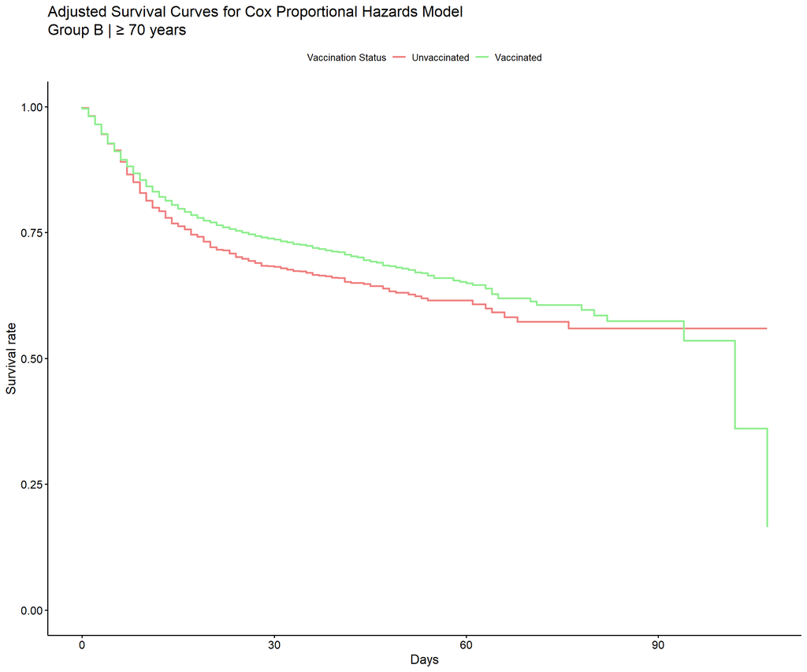

```r
# print the plot
print(ajusted_curve_B)
```

Age: >= 60

Admission date: after or equal 03/05/2021 + 14 days

```r
cat("Check the subset:\n")
```

```
## Check the subset:
```

```r
summary(df_over60[, c("age", "admission_datetime")])
```

```
##       age         admission_datetime
##  Min.   : 60.00   Min.   :2021-05-17
##  1st Qu.: 70.00   1st Qu.:2021-12-10
##  Median : 79.00   Median :2022-02-07
##  Mean   : 78.24   Mean   :2022-02-15
##  3rd Qu.: 86.00   3rd Qu.:2022-06-02
##  Max.   :105.00   Max.   :2022-11-28
```

```r
cat("\nNumber rows:", nrow(df_over60))
```

```
##
## Number rows: 13654
```

### 2.3.1 CoxPH refined (Group C)

```r
generate_coxph_analysis(df_over60,
                        included_vars,
                        "Over 60 years (Group C)",
                        num_table = 10,
                        num_fig = 14)
```

```
## [[1]]
##                                                         coef exp(coef)
## Vaccinated                                     -0.2216249682 0.8012158
## Sex Male                                       -0.1282755045 0.8796110
## Age                                             0.0643902263 1.0665085
## Medical Center Type Regional                   -0.0828817248 0.9204600
## Medical Center Type Specialty                  -0.1181800193 0.8885361
## ICU Stay                                        1.3309540740 3.7846525
## Preexisting Condition Active Cancer             0.2851476950 1.3299584
## Preexisting Condition Asthma                   -0.1058343578 0.8995736
## Preexisting Condition Congestive Heart Failure -0.0777970347 0.9251522
## Preexisting Condition Chronic Liver             0.0925725204 1.0969927
## Preexisting Condition Chronic Kidney Disease   -0.2353885067 0.7902638
## Preexisting Condition COPD                      0.0430103388 1.0439487
## Preexisting Condition Dementia                  0.0093236853 1.0093673
## Preexisting Condition Diabetes                 -0.0374705381 0.9632228
## Preexisting Condition Hyperlipidemia           -0.1209216384 0.8861034
## Preexisting Condition Hypertension             -0.0353140933 0.9653022
## Preexisting Condition Ischemic Heart Disease    0.1190267414 1.1264000
## Preexisting Condition Obesity                  -0.0512967890 0.9499967
## Preexisting Condition Stroke                   -0.0303595327 0.9700967
## C-Reactive Protein                              0.0013811303 1.0013821
## Glucose                                         0.0011311097 1.0011317
## Hematocrit                                     -0.0061534057 0.9938655
## Hemoglobin                                      0.0958876085 1.1006354
## Normalized Prothrombin Time - INR               0.0383241692 1.0390680
## Lactate Dehydrogenase                           0.0006617897 1.0006620
## Mean Corpuscular Hemoglobin                    -0.1997656950 0.8189226
## Mean Corpuscular Volume                         0.0593255269 1.0611206
## Neutrophil Percentage                           0.0144923788 1.0145979
## Platelet Count                                 -0.0013322478 0.9986686
## Red Blood Cell Count                           -0.3588272020 0.6984950
## Sodium                                          0.0114811229 1.0115473
## Urea                                            0.0056579144 1.0056740
##                                                    se(coef)           z
## Vaccinated                                     2.610505e-02  -8.4897369
## Sex Male                                       2.670726e-02  -4.8030204
## Age                                            1.276137e-03  50.4571381
## Medical Center Type Regional                   3.043320e-02  -2.7233981
## Medical Center Type Specialty                  3.079970e-02  -3.8370504
```

[output cut: 80 more lines]

```
## C-Reactive Protein                             1.0016486
## Glucose                                        1.0014196
## Hematocrit                                     0.9966529
## Hemoglobin                                     1.1800632
## Normalized Prothrombin Time - INR              1.0623171
## Lactate Dehydrogenase                          1.0007150
## Mean Corpuscular Hemoglobin                    0.8476428
## Mean Corpuscular Volume                        1.0690724
## Neutrophil Percentage                          1.0169750
## Platelet Count                                 0.9989425
## Red Blood Cell Count                           0.8622439
## Sodium                                         1.0159858
## Urea                                           1.0061337
##
## [[2]]
```

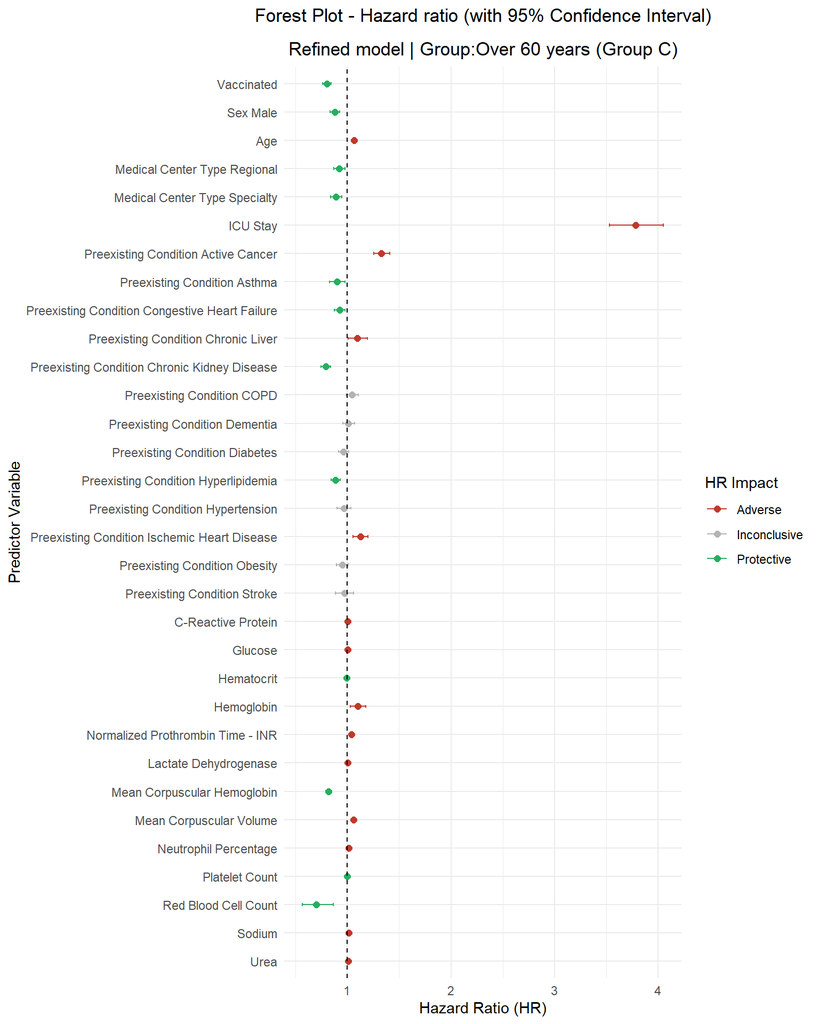

### 2.3.2. Adjusted Survival Curves for Cox Proportional Hazards Model (group C)

Comparison will be made between survival curves of individuals aged 60 and above, stratified based on vaccination status, following verification of admission dates.

```r
df_over60<-as.data.frame(df_over60)

df_over60$vaccinated <-factor(
  df_over60$vaccinated, levels = 0:1,
  labels = c("Unvaccinated", "Vaccinated")
)

vars_descriptives <- included_vars[included_vars != "vaccinated"]

# Create the formula
string_formula <- paste("Surv(Survival_in_days, Status) ~ strata(vaccinated) + ",
                          paste(vars_descriptives, collapse = " + "))
formula <- as.formula(string_formula)

# Fit the Cox proportional hazards model with stratification by vaccinated status
fit <- coxph(formula, data = df_over60)

# Plot adjusted survival curves stratified by vaccinated status
custom_colors <- c("Unvaccinated" = "#f08080", "Vaccinated" = "#90ee90")
title = "Adjusted Survival Curves for Cox Proportional Hazards Model\nGroup C | ≥ 60 years"
ajusted_curve_C <- ggadjustedcurves(fit,variable = 'vaccinated',
                                       legend.title = "Vaccination Status",
                                       main=title,
                                       palette=custom_colors,
                                       xlab='Days')
figure_number <- 15

# Save the plot as png
png(paste0("../OUTPUT_figures_tables/Figure_", figure_number, ".png"),
    width = 2400,
    height = 1600,
    res = 200,
    pointsize = 7)
print(ajusted_curve_C)
dev.off()
```

```r
#Save the plot as tiff
tiff(paste0("../OUTPUT_figures_tables/Figure_", figure_number, ".tiff"),
    width = 2400,
    height = 1600,
    res = 200,
    pointsize = 7)
print(ajusted_curve_C)
dev.off()
```

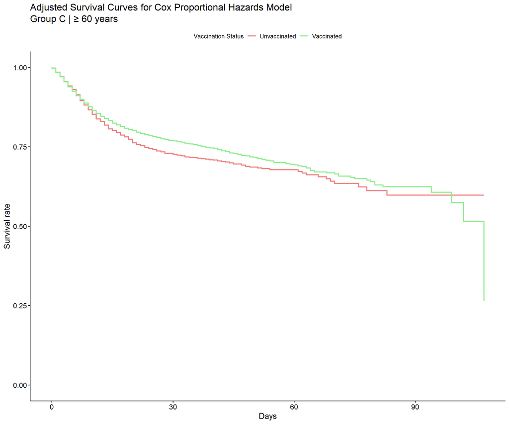

```r
# print the plot
print(ajusted_curve_C)
```

## 2.4. Analysis D: over 40

Age: >= 40

Admission date: after or equal 01/06/2021 + 14 days

```r
cat("Check the subset:\n")
```

```
## Check the subset:
```

```r
summary(df_over40[, c("age", "admission_datetime")])
```

```
##       age         admission_datetime
##  Min.   : 40.00   Min.   :2021-06-15
##  1st Qu.: 62.00   1st Qu.:2021-11-02
##  Median : 75.00   Median :2022-01-26
##  Mean   : 72.47   Mean   :2022-02-03
##  3rd Qu.: 85.00   3rd Qu.:2022-05-20
##  Max.   :105.00   Max.   :2022-11-28
```

```r
cat("\nNumber rows:", nrow(df_over40))
```

```
##
## Number rows: 16894
```

### 2.4.1 CoxPH refined (Group D)

```r
generate_coxph_analysis(df_over40,
                        included_vars,
                        "Over 40 years (Group D)",
                        num_table = 11,
                        num_fig = 16)
```

```
## [[1]]
##                                                         coef exp(coef)
## Vaccinated                                     -0.2216249682 0.8012158
## Sex Male                                       -0.1282755045 0.8796110
## Age                                             0.0643902263 1.0665085
## Medical Center Type Regional                   -0.0828817248 0.9204600
## Medical Center Type Specialty                  -0.1181800193 0.8885361
## ICU Stay                                        1.3309540740 3.7846525
## Preexisting Condition Active Cancer             0.2851476950 1.3299584
## Preexisting Condition Asthma                   -0.1058343578 0.8995736
## Preexisting Condition Congestive Heart Failure -0.0777970347 0.9251522
## Preexisting Condition Chronic Liver             0.0925725204 1.0969927
## Preexisting Condition Chronic Kidney Disease   -0.2353885067 0.7902638
## Preexisting Condition COPD                      0.0430103388 1.0439487
## Preexisting Condition Dementia                  0.0093236853 1.0093673
## Preexisting Condition Diabetes                 -0.0374705381 0.9632228
## Preexisting Condition Hyperlipidemia           -0.1209216384 0.8861034
## Preexisting Condition Hypertension             -0.0353140933 0.9653022
## Preexisting Condition Ischemic Heart Disease    0.1190267414 1.1264000
## Preexisting Condition Obesity                  -0.0512967890 0.9499967
## Preexisting Condition Stroke                   -0.0303595327 0.9700967
## C-Reactive Protein                              0.0013811303 1.0013821
## Glucose                                         0.0011311097 1.0011317
## Hematocrit                                     -0.0061534057 0.9938655
## Hemoglobin                                      0.0958876085 1.1006354
## Normalized Prothrombin Time - INR               0.0383241692 1.0390680
## Lactate Dehydrogenase                           0.0006617897 1.0006620
## Mean Corpuscular Hemoglobin                    -0.1997656950 0.8189226
## Mean Corpuscular Volume                         0.0593255269 1.0611206
## Neutrophil Percentage                           0.0144923788 1.0145979
## Platelet Count                                 -0.0013322478 0.9986686
## Red Blood Cell Count                           -0.3588272020 0.6984950
## Sodium                                          0.0114811229 1.0115473
## Urea                                            0.0056579144 1.0056740
##                                                    se(coef)           z
## Vaccinated                                     2.610505e-02  -8.4897369
## Sex Male                                       2.670726e-02  -4.8030204
## Age                                            1.276137e-03  50.4571381
## Medical Center Type Regional                   3.043320e-02  -2.7233981
## Medical Center Type Specialty                  3.079970e-02  -3.8370504
```

[output cut: 80 more lines]

```
## C-Reactive Protein                             1.0016486
## Glucose                                        1.0014196
## Hematocrit                                     0.9966529
## Hemoglobin                                     1.1800632
## Normalized Prothrombin Time - INR              1.0623171
## Lactate Dehydrogenase                          1.0007150
## Mean Corpuscular Hemoglobin                    0.8476428
## Mean Corpuscular Volume                        1.0690724
## Neutrophil Percentage                          1.0169750
## Platelet Count                                 0.9989425
## Red Blood Cell Count                           0.8622439
## Sodium                                         1.0159858
## Urea                                           1.0061337
##
## [[2]]
```

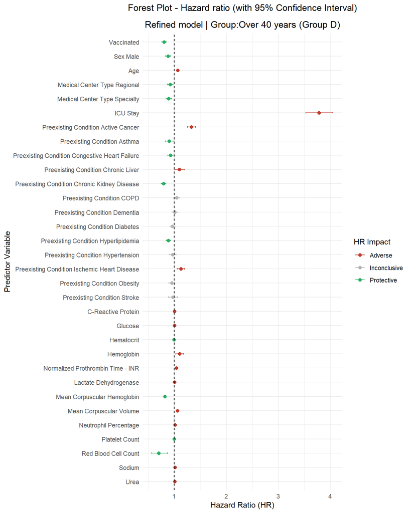

### 2.4.2. Adjusted Survival Curves for Cox Proportional Hazards Model (group D)

Comparison will be made between survival curves of individuals aged 40 and above, stratified based on vaccination status, following verification of admission dates.

```r
df_over40<-as.data.frame(df_over40)

df_over40$vaccinated <-factor(
  df_over40$vaccinated, levels = 0:1,
  labels = c("Unvaccinated", "Vaccinated")
)

vars_descriptives <- included_vars[included_vars != "vaccinated"]

# Create the formula
string_formula <- paste("Surv(Survival_in_days, Status) ~ strata(vaccinated) + ",
                          paste(vars_descriptives, collapse = " + "))
formula <- as.formula(string_formula)

# Fit the Cox proportional hazards model with stratification by vaccinated status
fit <- coxph(formula, data = df_over40)

# Plot adjusted survival curves stratified by vaccinated status
custom_colors <- c("Unvaccinated" = "#f08080", "Vaccinated" = "#90ee90")
title = "Adjusted Survival Curves for Cox Proportional Hazards Model\nGroup D | ≥ 40 years"
ajusted_curve_D <- ggadjustedcurves(fit,variable = 'vaccinated',
                                       legend.title = "Vaccination Status",
                                       main=title,
                                       palette=custom_colors,
                                       xlab='Days')
figure_number <- 17

# Save the plot as png
png(paste0("../OUTPUT_figures_tables/Figure_", figure_number, ".png"),
    width = 2400,
    height = 1600,
    res = 200,
    pointsize = 7)
print(ajusted_curve_D)
dev.off()
```

```r
#Save the plot as tiff
tiff(paste0("../OUTPUT_figures_tables/Figure_", figure_number, ".tiff"),
    width = 2400,
    height = 1600,
    res = 200,
    pointsize = 7)
print(ajusted_curve_D)
dev.off()
```

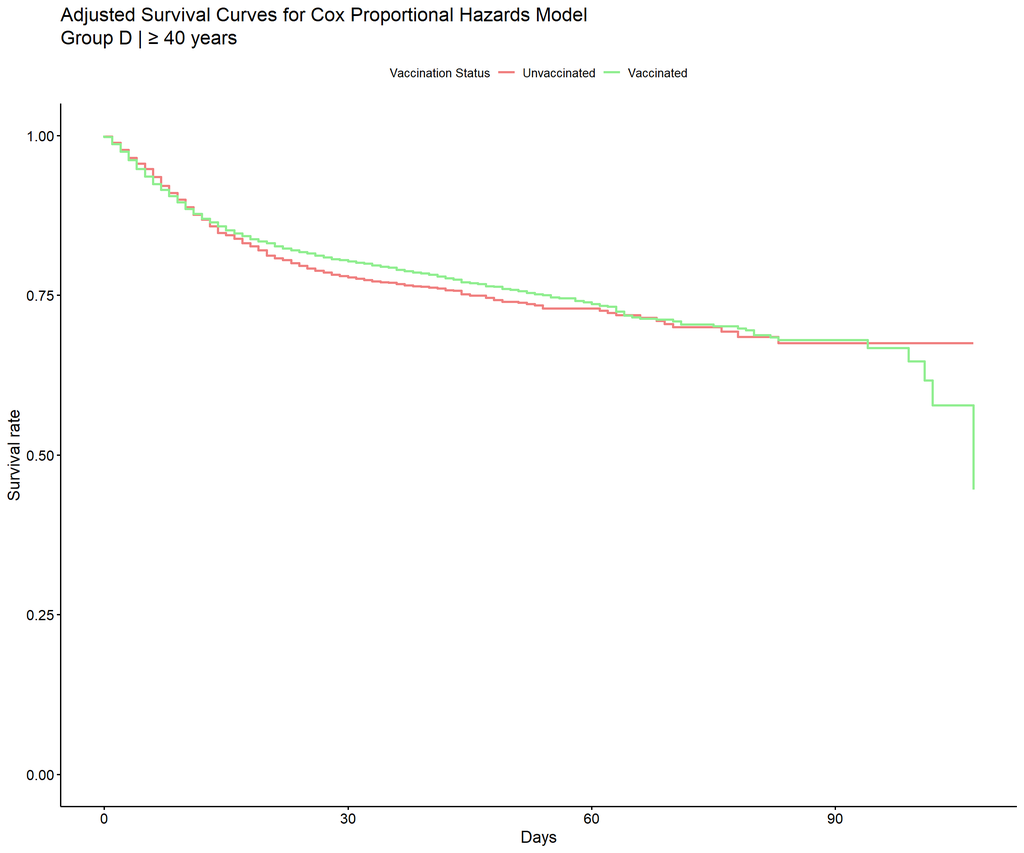

```r
# print the plot
print(ajusted_curve_D)
```

## 2.5. Analysis E: over 18

Age: >= 18

Admission date: after or equal 20/07/2021 + 14 days

```r
cat("Check the subset:\n")
```

```
## Check the subset:
```

```r
summary(df_over18[, c("age", "admission_datetime")])
```

```
##       age         admission_datetime
##  Min.   : 18.00   Min.   :2021-08-03
##  1st Qu.: 61.00   1st Qu.:2021-12-23
##  Median : 75.00   Median :2022-02-02
##  Mean   : 71.55   Mean   :2022-02-22
##  3rd Qu.: 85.00   3rd Qu.:2022-05-27
##  Max.   :105.00   Max.   :2022-11-28
```

```r
cat("\nNumber rows:", nrow(df_over18))
```

```
##
## Number rows: 15961
```

```r
generate_coxph_analysis(df_over18,
                        included_vars,
                        "Over 18 years (Group E)",
                        num_table = 12,
                        num_fig = 18)
```

```
## [[1]]
##                                                         coef exp(coef)
## Vaccinated                                     -0.2216249682 0.8012158
## Sex Male                                       -0.1282755045 0.8796110
## Age                                             0.0643902263 1.0665085
## Medical Center Type Regional                   -0.0828817248 0.9204600
## Medical Center Type Specialty                  -0.1181800193 0.8885361
## ICU Stay                                        1.3309540740 3.7846525
## Preexisting Condition Active Cancer             0.2851476950 1.3299584
## Preexisting Condition Asthma                   -0.1058343578 0.8995736
## Preexisting Condition Congestive Heart Failure -0.0777970347 0.9251522
## Preexisting Condition Chronic Liver             0.0925725204 1.0969927
## Preexisting Condition Chronic Kidney Disease   -0.2353885067 0.7902638
## Preexisting Condition COPD                      0.0430103388 1.0439487
## Preexisting Condition Dementia                  0.0093236853 1.0093673
## Preexisting Condition Diabetes                 -0.0374705381 0.9632228
## Preexisting Condition Hyperlipidemia           -0.1209216384 0.8861034
## Preexisting Condition Hypertension             -0.0353140933 0.9653022
## Preexisting Condition Ischemic Heart Disease    0.1190267414 1.1264000
## Preexisting Condition Obesity                  -0.0512967890 0.9499967
## Preexisting Condition Stroke                   -0.0303595327 0.9700967
## C-Reactive Protein                              0.0013811303 1.0013821
## Glucose                                         0.0011311097 1.0011317
## Hematocrit                                     -0.0061534057 0.9938655
## Hemoglobin                                      0.0958876085 1.1006354
## Normalized Prothrombin Time - INR               0.0383241692 1.0390680
## Lactate Dehydrogenase                           0.0006617897 1.0006620
## Mean Corpuscular Hemoglobin                    -0.1997656950 0.8189226
## Mean Corpuscular Volume                         0.0593255269 1.0611206
## Neutrophil Percentage                           0.0144923788 1.0145979
## Platelet Count                                 -0.0013322478 0.9986686
## Red Blood Cell Count                           -0.3588272020 0.6984950
## Sodium                                          0.0114811229 1.0115473
## Urea                                            0.0056579144 1.0056740
##                                                    se(coef)           z
## Vaccinated                                     2.610505e-02  -8.4897369
## Sex Male                                       2.670726e-02  -4.8030204
## Age                                            1.276137e-03  50.4571381
## Medical Center Type Regional                   3.043320e-02  -2.7233981
## Medical Center Type Specialty                  3.079970e-02  -3.8370504
```

[output cut: 80 more lines]

```
## C-Reactive Protein                             1.0016486
## Glucose                                        1.0014196
## Hematocrit                                     0.9966529
## Hemoglobin                                     1.1800632
## Normalized Prothrombin Time - INR              1.0623171
## Lactate Dehydrogenase                          1.0007150
## Mean Corpuscular Hemoglobin                    0.8476428
## Mean Corpuscular Volume                        1.0690724
## Neutrophil Percentage                          1.0169750
## Platelet Count                                 0.9989425
## Red Blood Cell Count                           0.8622439
## Sodium                                         1.0159858
## Urea                                           1.0061337
##
## [[2]]
```

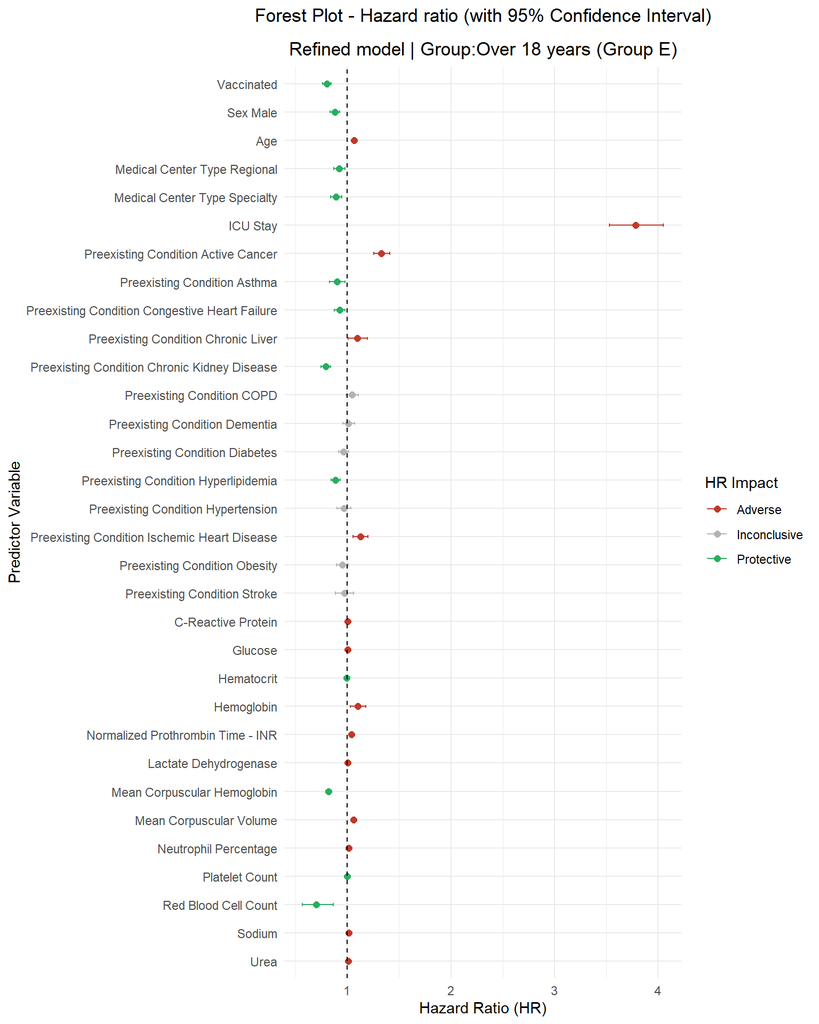

Comparison will be made between survival curves of individuals aged 18 and above, stratified based on vaccination status, following verification of admission dates.

```r
df_over18<-as.data.frame(df_over18)

df_over18$vaccinated <-factor(
  df_over18$vaccinated, levels = 0:1,
  labels = c("Unvaccinated", "Vaccinated")
)

vars_descriptives <- included_vars[included_vars != "vaccinated"]

# Create the formula
string_formula <- paste("Surv(Survival_in_days, Status) ~ strata(vaccinated) + ",
                          paste(vars_descriptives, collapse = " + "))
formula <- as.formula(string_formula)

# Fit the Cox proportional hazards model with stratification by vaccinated status
fit <- coxph(formula, data = df_over18)

# Plot adjusted survival curves stratified by vaccinated status
custom_colors <- c("Unvaccinated" = "#f08080", "Vaccinated" = "#90ee90")
title = "Adjusted Survival Curves for Cox Proportional Hazards Model\nGroup E | ≥ 18 years"
ajusted_curve_E <- ggadjustedcurves(fit,variable = 'vaccinated',
                                       legend.title = "Vaccination Status",
                                       main=title,
                                       palette=custom_colors,
                                       xlab='Days')
figure_number <- 19

# Save the plot as png
png(paste0("../OUTPUT_figures_tables/Figure_", figure_number, ".png"),
    width = 2400,
    height = 1600,
    res = 200,
    pointsize = 7)
print(ajusted_curve_E)
dev.off()
```

```r
#Save the plot as tiff
tiff(paste0("../OUTPUT_figures_tables/Figure_", figure_number, ".tiff"),
    width = 2400,
    height = 1600,
    res = 200,
    pointsize = 7)
print(ajusted_curve_E)
dev.off()
```

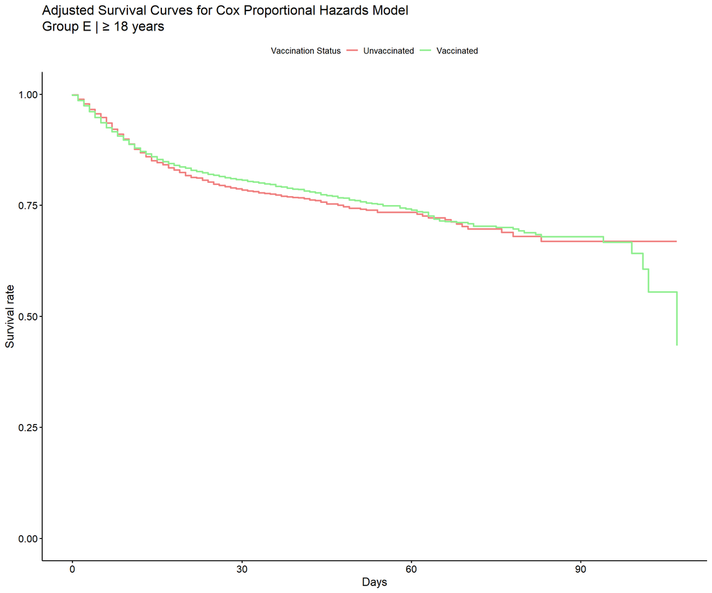

```r
# print the plot
print(ajusted_curve_E)
```

## 2.6 Summary subanalysis

```r
list_subplots <- list(ajusted_curve_A, ajusted_curve_B, ajusted_curve_C, ajusted_curve_D, ajusted_curve_E)
plot_grid <- plot_grid(plotlist = list_subplots, nrow=2, ncol=3)

n_figure <- 20

# Save as png
png(paste("../OUTPUT_figures_tables/Figure_", n_figure, ".png", sep=""),
    width = 40*120,
    height = 25*120,
    res = 200,
    pointsize = 7)
print(plot_grid)
dev.off()
```

```r
# Save as tiff
tiff(paste("../OUTPUT_figures_tables/Figure_", n_figure, ".tiff", sep=""),
    width = 40*120,
    height = 25*120,
    res = 200,
    pointsize = 7)
print(plot_grid)
dev.off()
```

```r
# Plot
print(plot_grid)
```

[figure not shown]

# 3. Analysis 3: Immunization Stratification: Unprotected, Protected (≥ 3 Doses, last within 180 Days), Incomplete protection

## 3.1. Load the vaccination dataframe

```r
vacc_df <- read.csv("../../0_get_data/data/04_Vacunacion_covid.txt", sep = '|')
vacc_df$FEC_VACUNACION <- as.Date(as.character(vacc_df$FEC_VACUNACION), format = "%Y%m%d")
```

## 3.2. Stratification in 3 groups

```r
# Remove previous vaccination info
df$vaccinated <- NA

# Merge both df
merged_df <- merge(df, vacc_df, by.x = "id", by.y = "NUHSA_ENCRIPTADO", all.x = TRUE)

# UNPROTECTED
id_unprotected <- merged_df[is.na(merged_df$FEC_VACUNACION), "id"]
df$vaccinated[df$id %in% id_unprotected] <- "Unprotected"

# All vaccines before admission are not count
merged_df <- merged_df %>%
  filter(FEC_VACUNACION +14 < admission_datetime)

# PROTECTED
df_protected <- merged_df %>%
  group_by(id) %>%
  filter(n() >= 3) %>%
  summarize(
    last_dosis_date = max(FEC_VACUNACION, na.rm = TRUE),
    admission_datetime = first(admission_datetime)  # All values are the same for admission_datetime
  ) %>%
  ungroup() %>%
  mutate(days_last_dosis = as.numeric(difftime(admission_datetime, last_dosis_date, units = "days")))

id_protected <- df_protected %>% filter(days_last_dosis <= 180) %>% pull(id)

df$vaccinated[df$id %in% id_protected] <- "Protected"

# INCOMPLETE
others_id <- subset(df, is.na(vaccinated))$id
df_incomplete <- merged_df %>%
  filter(id %in% others_id) %>%
  group_by(id) %>%
  filter(n() > 0 & n() < 3) %>%
  summarize(
    last_dosis_date = max(FEC_VACUNACION, na.rm = TRUE),
    admission_datetime = first(admission_datetime)  # All values are the same for admission_datetime
  ) %>%
  ungroup %>%
  mutate(days_last_dosis = as.numeric(difftime(admission_datetime, last_dosis_date, units = "days"))) %>%
  filter(days_last_dosis > 180)

id_incomplete <-  df_incomplete %>% pull(id)

df$vaccinated[df$id %in% id_incomplete] <- "Incomplete"


# REMOVE OTHER CASES
df <- df[complete.cases(df$vaccinated), ]


# Set as factor
df$vaccinated <- as.factor(df$vaccinated)
df$vaccinated <- factor(df$vaccinated, levels = c("Unprotected", "Protected", "Incomplete"))

# Count each possible level
cat("Vaccination subgroups:")
```

```
## Vaccination subgroups:
```

```r
print(table(df$vaccinated))
```

```
##
## Unprotected   Protected  Incomplete
##        6537        4092        2806
```

## 3.3 CoxPH refined

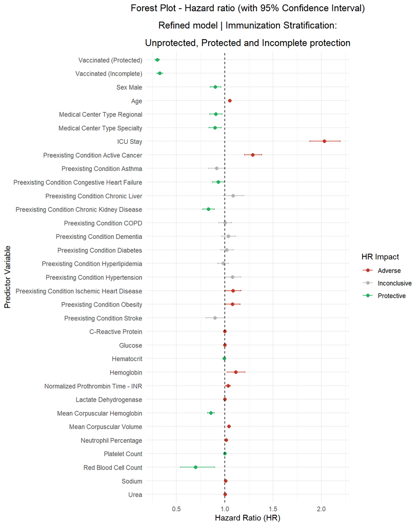

```r
# Create the formula
formula_string <- paste("Surv(Survival_in_days, Status) ~", paste(included_vars, collapse = " + "))
formula <- as.formula(formula_string)

# Model
cox_model_3 <- coxph(formula, data = df)

# Extract the model report
cox_model_summary_3 <- summary(cox_model_3)

# Extract the relevant_data
coefficients <- as.data.frame(cox_model_summary_3$coefficients)
intervals <- as.data.frame(cox_model_summary_3$conf.int)

# Combine both df with relevant info
cox_model_report3 <- cbind(coefficients, intervals[, c("lower .95", "upper .95")])

remap_rows = remap_rows <- c(
  "vaccinatedProtected" = "Vaccinated (Protected)",
  "vaccinatedIncomplete" = "Vaccinated (Incomplete)",
  "sexMale" = "Sex Male",
  "age" = "Age",
  "type_centerSpecialized Hospital" = "Medical Center Type Specialty",
  "type_centerRegional Hospital" = "Medical Center Type Regional",
  "icu" = "ICU Stay",
  "wavewave_3" = "Wave 3",
  "wavewave_4" = "Wave 4",
  "wavewave_5" = "Wave 5",
  "wavewave_6" = "Wave 6",
  "wavewave_7" = "Wave 7",
  "pmhx_activecancer" = "Preexisting Condition Active Cancer",
  "pmhx_asthma" = "Preexisting Condition Asthma",
  "pmhx_chf" = "Preexisting Condition Congestive Heart Failure",
  "pmhx_chronicliver" = "Preexisting Condition Chronic Liver",
  "pmhx_ckd" = "Preexisting Condition Chronic Kidney Disease",
  "pmhx_copd" = "Preexisting Condition COPD",
  "pmhx_dementia" = "Preexisting Condition Dementia",
  "pmhx_diabetes" = "Preexisting Condition Diabetes",
  "pmhx_hld" = "Preexisting Condition Hyperlipidemia",
  "pmhx_htn" = "Preexisting Condition Hypertension",
  "pmhx_ihd" = "Preexisting Condition Ischemic Heart Disease",
  "pmhx_obesity" = "Preexisting Condition Obesity",
  "pmhx_stroke" = "Preexisting Condition Stroke",
  "lab_alt" = "Alanine Transaminase",
  "lab_ast" = "Aspartate Transaminase",
  "lab_creatinine" = "Creatinine",
  "lab_crp" = "C-Reactive Protein",
  "lab_ddimer" = "D-Dimer",
  "lab_glucose" = "Glucose",
  "lab_hct" = "Hematocrit",
  "lab_hemoglobin" = "Hemoglobin",
  "lab_inr" = "Normalized Prothrombin Time - INR",
  "lab_ldh" = "Lactate Dehydrogenase",
  "lab_leukocyte" = "Leukocyte Count",
  "lab_lymphocyte" = "Lymphocyte Count",
  "lab_lymphocyte_percentage" = "Lymphocyte Percentage",
  "lab_mch" = "Mean Corpuscular Hemoglobin",
  "lab_mcv" = "Mean Corpuscular Volume",
  "lab_neutrophil" = "Neutrophil Count",
  "lab_neutrophil_percentage" = "Neutrophil Percentage",
  "lab_platelet" = "Platelet Count",
  "lab_potassium" = "Potassium",
  "lab_rbc" = "Red Blood Cell Count",
  "lab_sodium" = "Sodium",
  "lab_urea" = "Urea"
)

# Assign new row names using the mapper, with handling for NA
new_row_names <- ifelse(rownames(cox_model_report3) %in% names(remap_rows),
                        remap_rows[rownames(cox_model_report3)],
                        rownames(cox_model_report3))

# Assign the new row names to the DataFrame
rownames(cox_model_report3) <- new_row_names

num_table <- 13
# Save the report in excel
excel_path <- paste0("../OUTPUT_figures_tables/Table_", num_table, "_Cox_Model_Report_", "Stratification Unprotected, Protected and Incomplete",".xlsx")
#
cox_model_report_excel <- cox_model_report3 %>%
  mutate(variables = row.names(cox_model_report3)) %>%
  select(variables, everything())
write_xlsx(cox_model_report_excel, excel_path)

# create the foresplot
plot_title <- "Forest Plot - Hazard ratio (with 95% Confidence Interval)\nRefined model | Immunization Stratification:\nUnprotected, Protected and Incomplete protection"
foresplot <- create_forest_plot(cox_model_report3, plot_title, 21)
print(foresplot)
```

## 3.4 Adjusted Survival Curves for Stratification into 3 groups

```r
df<-as.data.frame(df)

vars_descriptives <- included_vars[included_vars != "vaccinated"]

# Create the formula
string_formula <- paste("Surv(Survival_in_days, Status) ~ strata(vaccinated) + ",
                          paste(vars_descriptives, collapse = " + "))
formula <- as.formula(string_formula)

# Fit the Cox proportional hazards model with stratification by vaccinated status
fit <- coxph(formula, data = df)

# Plot adjusted survival curves stratified by vaccinated status
custom_colors <- c("Unprotected" = "#AB6BEA", "Protected" = "#54EB86", "Incomplete" = "#EBAF54")
title = "Adjusted Survival Curves for Cox Proportional Hazards Model\nImmunization Stratification:\nUnprotected, Protected and Incomplete protection"
ajusted_curve_3 <- ggadjustedcurves(fit,variable = 'vaccinated',
                                       legend.title = "Vaccination Status",
                                       main=title,
                                       palette=custom_colors,
                                       xlab='Days')
figure_number <- 22

# Save the plot as png
png(paste0("../OUTPUT_figures_tables/Figure_", figure_number, ".png"),
    width = 2400,
    height = 1600,
    res = 200,
    pointsize = 7)
print(ajusted_curve_3)
dev.off()
```

```r
#Save the plot as tiff
tiff(paste0("../OUTPUT_figures_tables/Figure_", figure_number, ".tiff"),
    width = 2400,
    height = 1600,
    res = 200,
    pointsize = 7)
print(ajusted_curve_3)
dev.off()
```

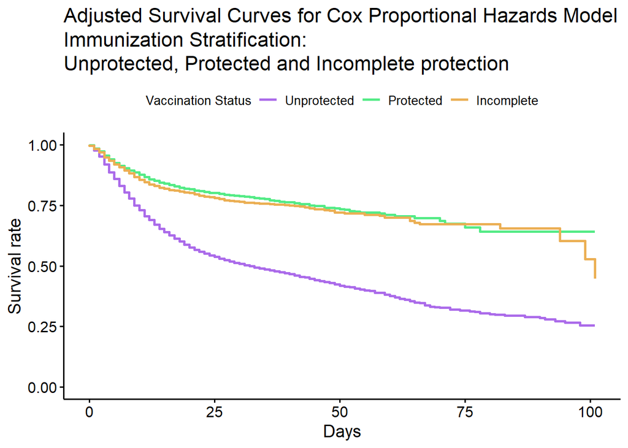

```r
# print the plot
print(ajusted_curve_3)
```